# Lesson 4

### Scatterplots and Perceived Audience Size

Notes: Scatterplots can be used to quickly see the relationships between 2 variables. ***

### Scatterplots

Notes: CONTINUOUS VARIABLE - variable that has an infinite number of possible values, a DISCRETE variable can only have a certain number of values.

TSV - tab seperated value, read in with ‘read.delim(x)’

```r
library(dplyr)
library(alr3)
```

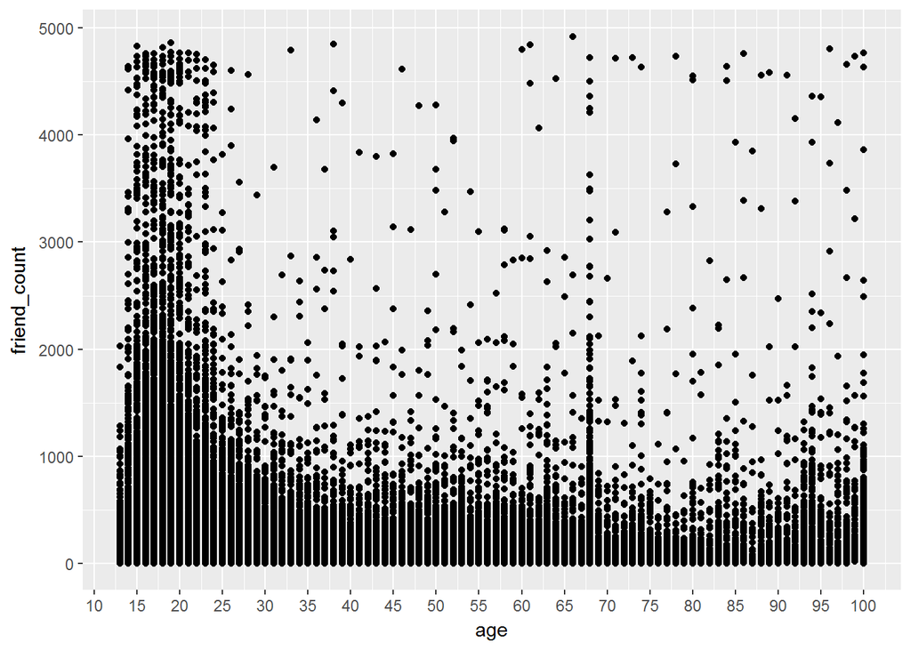

```r
library(ggplot2)
pf <- read.delim('pseudo_facebook.tsv')

#qplot syntax
#qplot(age, friend_count, data = pf)

#ggplot syntax

ggplot(aes(x=age, y=friend_count), data = pf) +
    geom_point() +
    scale_x_continuous(limits = c(13,100), breaks = seq(0,100,5))
```

#### What are some things that you notice right away?

Response: Younger people tend to have more friends on average. There are some outliers at a few specific ages.

### ggplot Syntax

Notes: ggplot syntax is more verbose than qplot, must wrap variables in aes() wrapper.

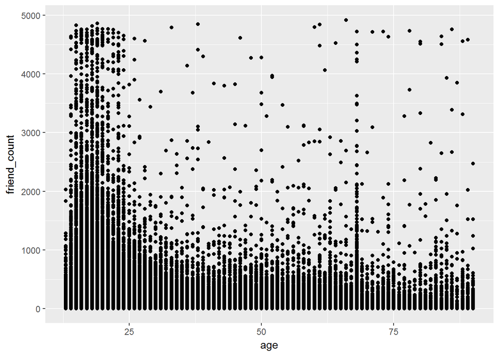

```r
#adding xlim
ggplot(aes(x=age, y=friend_count), data = pf) +
    geom_point() +
    xlim(13,90)
```

```r
    #scale_x_continuous(limits = c(13,100), breaks = seq(0,100,5))
```

### Overplotting

Notes: overplotting makes it hard to distinguish the graphs characteristics, can use alpha level to change transparency

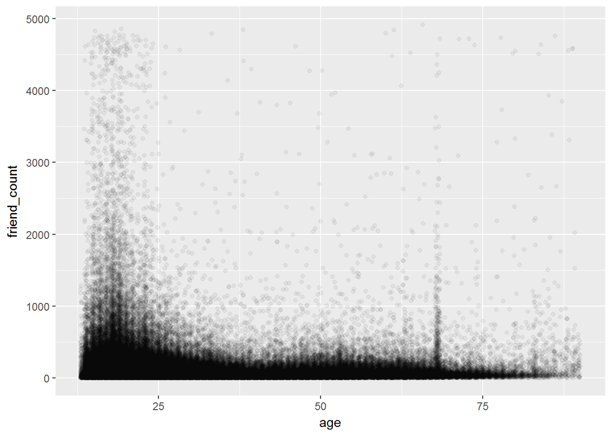

```r
ggplot(aes(x=age, y=friend_count), data = pf) +
    #alpha allows you to see the distribution of data points, takes 20 data points for a point in the graph to be completely dark
    #jitter introduces some noise to the data, breaking up the lines seen in the first graph above
    geom_jitter(alpha = 1/20) +
    xlim(13,90)
```

### Coord_trans()

Notes:Cartesian coordinate system transformation

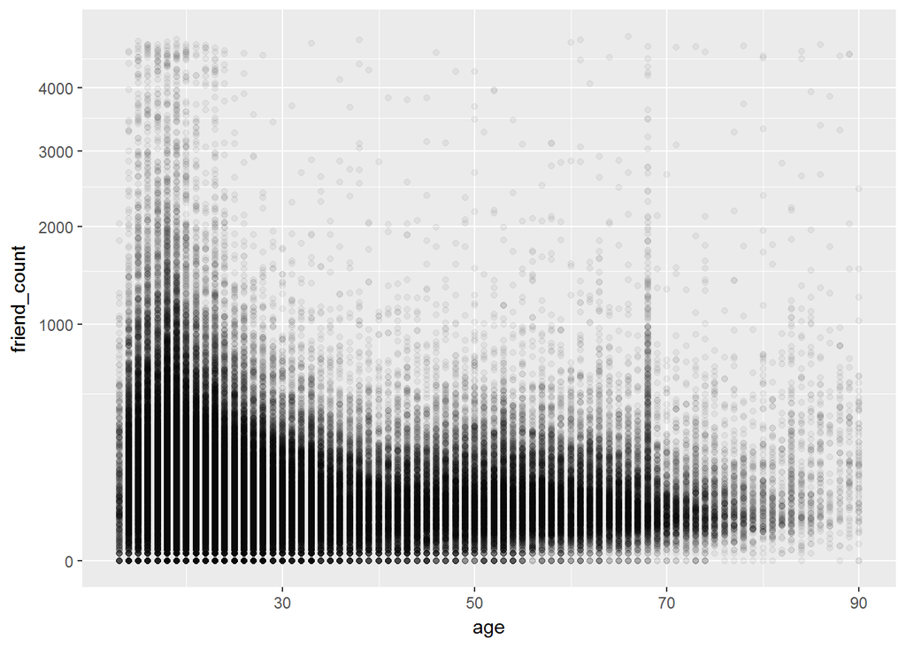

```r
ggplot(aes(x=age, y=friend_count), data = pf) +
    geom_point(alpha = 1/20) +
    xlim(13,90) +
    coord_trans(y = 'sqrt')
```

#### Look up the documentation for coord_trans() and add a layer to the plot that transforms friend_count using the square root function. Create your plot!

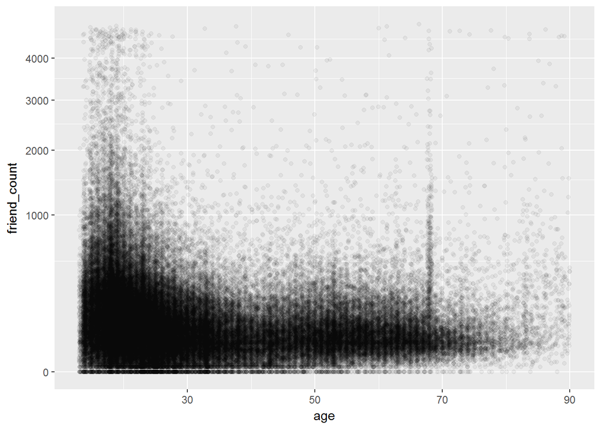

```r
#redoing the above plot with jitter
ggplot(aes(x=age, y=friend_count), data = pf) +
    geom_point(alpha = 1/20, position = position_jitter(h=0)) +
    xlim(13,90) +
    coord_trans(y = 'sqrt')
```

### Alpha and Jitter

Notes:Explore the relationship between friendships initiated and age

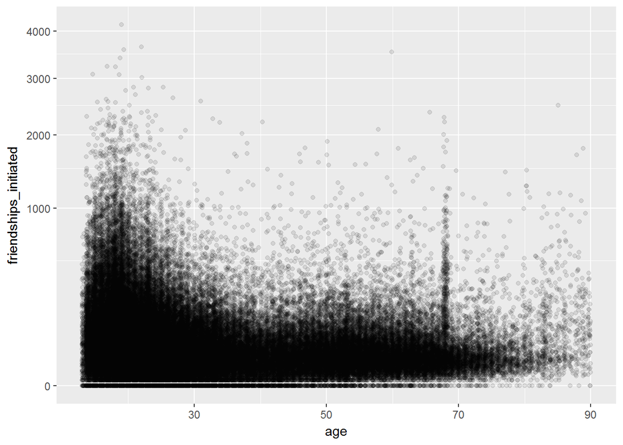

```r
ggplot(aes(x=age, y = friendships_initiated), data = pf) +
    geom_jitter(alpha = 1/10, position = position_jitter(h = 0)) +
    xlim(13,90) +
    coord_trans(y = 'sqrt')
```

```r
age_groups <- group_by(pf, age)

head(age_groups)
```

```
## Source: local data frame [6 x 15]
## Groups: age [1]
##
##    userid   age dob_day dob_year dob_month gender tenure friend_count
##     <int> <int>   <int>    <int>     <int> <fctr>  <int>        <int>
## 1 2094382    14      19     1999        11   male    266            0
## 2 1192601    14       2     1999        11 female      6            0
## 3 2083884    14      16     1999        11   male     13            0
## 4 1203168    14      25     1999        12 female     93            0
## 5 1733186    14       4     1999        12   male     82            0
## 6 1524765    14       1     1999        12   male     15            0
## # ... with 7 more variables: friendships_initiated <int>, likes <int>,
## #   likes_received <int>, mobile_likes <int>, mobile_likes_received <int>,
## #   www_likes <int>, www_likes_received <int>
```

```r
pf.fc_by_age <- summarise(age_groups,
                          friend_count_mean = mean(friend_count),
                          friend_count_median = median(friend_count),
                          n=n())

pf.fc_by_age <- arrange(pf.fc_by_age, age)

head(pf.fc_by_age)
```

```
## # A tibble: 6 × 4
##     age friend_count_mean friend_count_median     n
##   <int>             <dbl>               <dbl> <int>
## 1    13          164.7500                74.0   484
## 2    14          251.3901               132.0  1925
## 3    15          347.6921               161.0  2618
## 4    16          351.9371               171.5  3086
## 5    17          350.3006               156.0  3283
## 6    18          331.1663               162.0  5196
```

```r
#alternate method to do the above

pf.fc_by_age2 <- pf %>%
    group_by(age) %>%
    summarise(friend_count_mean = mean(friend_count),
              friend_count_median = median(friend_count),
              n = n()) %>%
    arrange(age)

head(pf.fc_by_age2, 20)
```

```
## # A tibble: 20 × 4
##      age friend_count_mean friend_count_median     n
##    <int>             <dbl>               <dbl> <int>
## 1     13          164.7500                74.0   484
## 2     14          251.3901               132.0  1925
## 3     15          347.6921               161.0  2618
## 4     16          351.9371               171.5  3086
## 5     17          350.3006               156.0  3283
## 6     18          331.1663               162.0  5196
## 7     19          333.6921               157.0  4391
## 8     20          283.4991               135.0  3769
## 9     21          235.9412               121.0  3671
## 10    22          211.3948               106.0  3032
## 11    23          202.8426                93.0  4404
## 12    24          185.7121                92.0  2827
## 13    25          131.0211                62.0  3641
## 14    26          144.0082                75.0  2815
## 15    27          134.1473                72.0  2240
## 16    28          125.8354                66.0  2364
## 17    29          120.8182                66.0  1936
## 18    30          115.2080                67.5  1716
## 19    31          118.4599                63.0  1694
## 20    32          114.2800                63.0  1443
```

Create your plot!

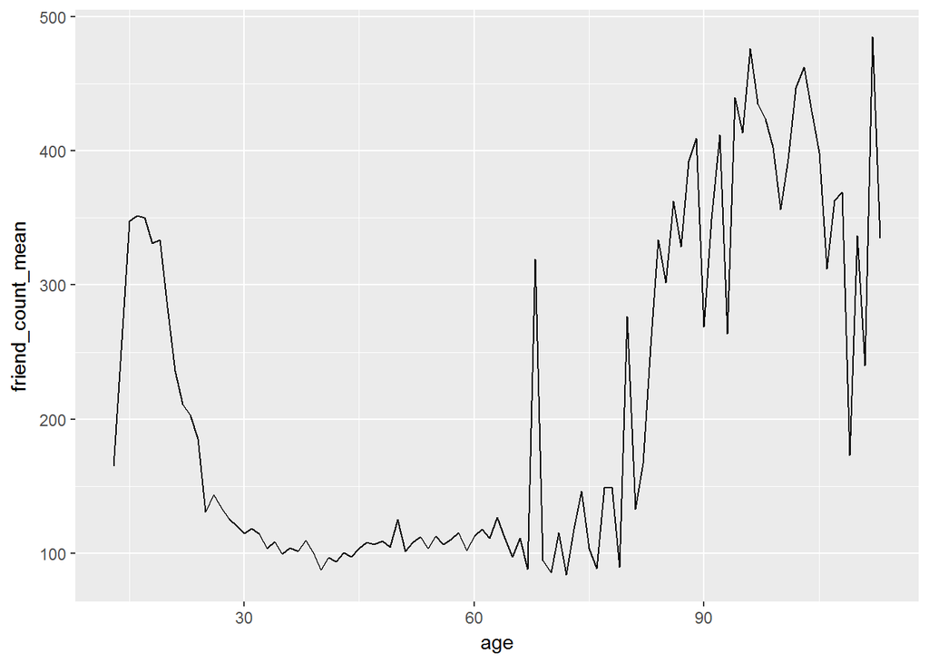

```r
ggplot(aes(x = age, y = friend_count_mean), data = pf.fc_by_age2) +
    geom_line()
```

```r
    #xlim(13,90)
```

### Overlaying Summaries with Raw Data

Notes:

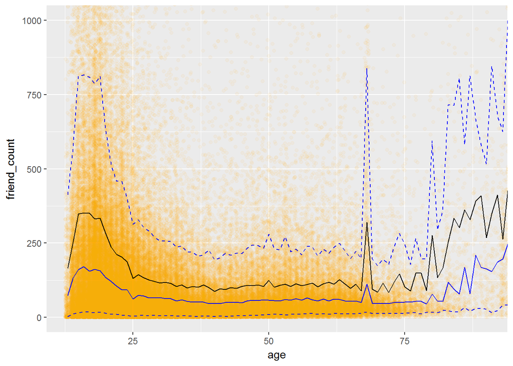

```r
ggplot(aes(x=age, y=friend_count), data = pf) +
    coord_cartesian(xlim = c(13, 90), ylim = c(0,1000)) +
    #xlim(13,90) +
    geom_point(alpha = 1/20,
               position = position_jitter(h=0),
               color = 'orange') +
    #coord_trans(y = 'sqrt') +
    geom_line(stat = 'summary', fun.y = mean) +
    geom_line(stat = 'summary', fun.y = quantile, fun.args = list(probs = .1), linetype = 2, color = 'blue') +
    geom_line(stat = 'summary', fun.y = quantile, fun.args = list(probs = .9), linetype = 2, color = 'blue') +
    geom_line(stat = 'summary', fun.y = quantile, fun.args = list(probs = .5), color = 'blue')
```

### Correlation

Notes: Pearson’s r

```r
cor.test(pf$age, pf$friend_count, method = 'pearson')
```

```
##
##  Pearson's product-moment correlation
##
## data:  pf$age and pf$friend_count
## t = -8.6268, df = 99001, p-value < 2.2e-16
## alternative hypothesis: true correlation is not equal to 0
## 95 percent confidence interval:
##  -0.03363072 -0.02118189
## sample estimates:
##         cor
## -0.02740737
```

```r
#alternate syntax to calculate pearson's r, cor.test defaults to pearson
with(pf, cor.test(age,friend_count, method = 'pearson'))
```

```
##
##  Pearson's product-moment correlation
##
## data:  age and friend_count
## t = -8.6268, df = 99001, p-value < 2.2e-16
## alternative hypothesis: true correlation is not equal to 0
## 95 percent confidence interval:
##  -0.03363072 -0.02118189
## sample estimates:
##         cor
## -0.02740737
```

Look up the documentation for the cor.test function.

What’s the correlation between age and friend count? Round to three decimal places. Response:

### Correlation on Subsets

Notes:

```r
with(subset(pf, age <= 70), cor.test(age, friend_count))
```

```
##
##  Pearson's product-moment correlation
##
## data:  age and friend_count
## t = -52.592, df = 91029, p-value < 2.2e-16
## alternative hypothesis: true correlation is not equal to 0
## 95 percent confidence interval:
##  -0.1780220 -0.1654129
## sample estimates:
##        cor
## -0.1717245
```

### Correlation Methods

Notes:

```r
with(subset(pf, age <= 70), cor.test(age, friend_count, method = 'spearman'))
```

```
##
##  Spearman's rank correlation rho
##
## data:  age and friend_count
## S = 1.5782e+14, p-value < 2.2e-16
## alternative hypothesis: true rho is not equal to 0
## sample estimates:
##        rho
## -0.2552934
```

## Create Scatterplots

Notes:

```r
with(subset(pf, age <= 70), cor.test(age, friend_count, method = 'spearman'))
```

```
##
##  Spearman's rank correlation rho
##
## data:  age and friend_count
## S = 1.5782e+14, p-value < 2.2e-16
## alternative hypothesis: true rho is not equal to 0
## sample estimates:
##        rho
## -0.2552934
```

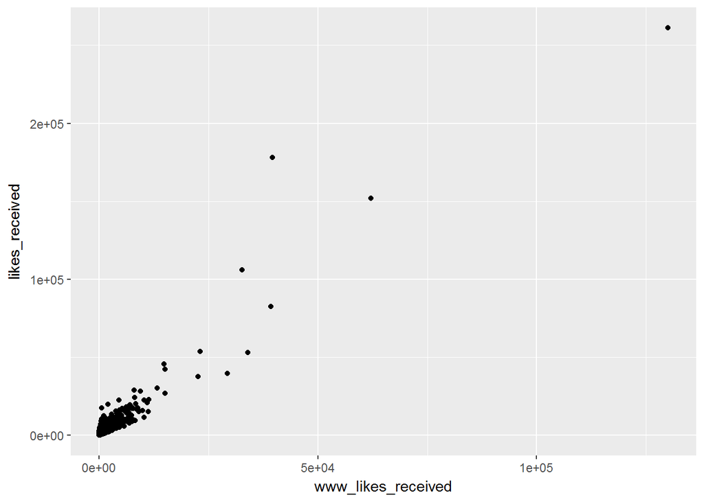

```r
ggplot(aes(x = www_likes_received, y = likes_received), data = pf) +
    geom_point()
```

### Strong Correlations

Notes:

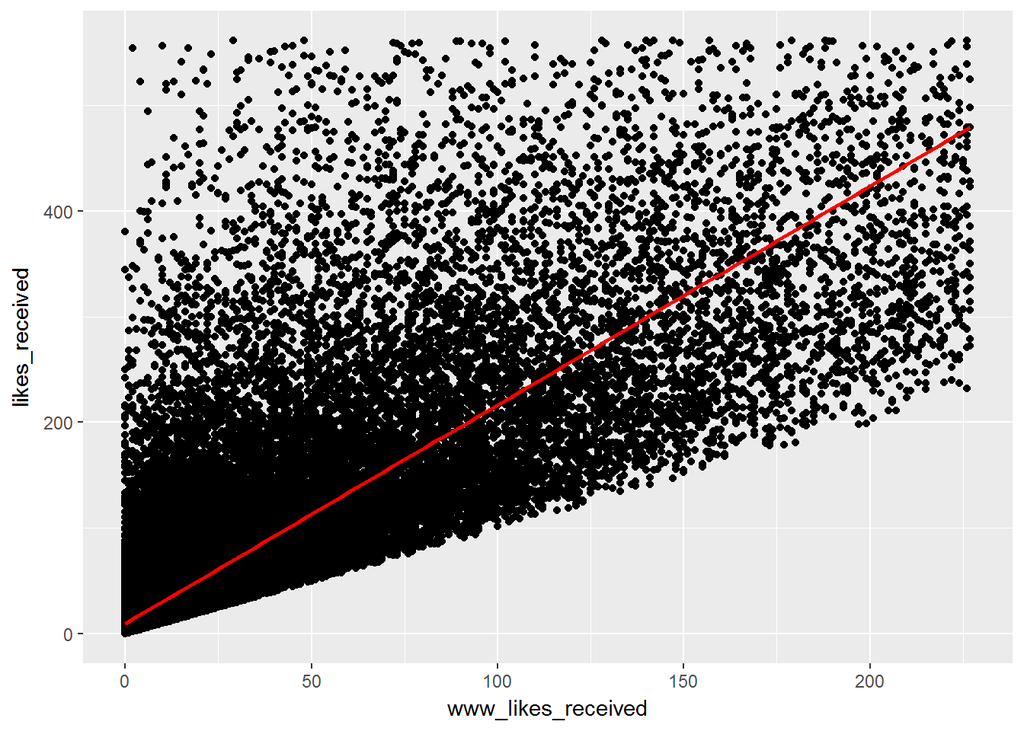

```r
ggplot(aes(x = www_likes_received, y = likes_received), data = pf) +
    geom_point() +
    xlim(0, quantile(pf$www_likes_received, 0.95)) +
    ylim(0, quantile(pf$likes_received, 0.95)) +
    #line of best fit
    geom_smooth(method = 'lm', color = 'red')
```

What’s the correlation betwen the two variables? Include the top 5% of values for the variable in the calculation and round to 3 decimal places.

```r
cor.test(pf$www_likes_received, pf$likes_received, method = 'pearson')
```

```
##
##  Pearson's product-moment correlation
##
## data:  pf$www_likes_received and pf$likes_received
## t = 937.1, df = 99001, p-value < 2.2e-16
## alternative hypothesis: true correlation is not equal to 0
## 95 percent confidence interval:
##  0.9473553 0.9486176
## sample estimates:
##       cor
## 0.9479902
```

Response:

### Moira on Correlation

Notes: important to measure correlation between variables, especially if you are going to do regressions

### More Caution with Correlation

Notes:

```r
data(Mitchell)
```

Create your plot!

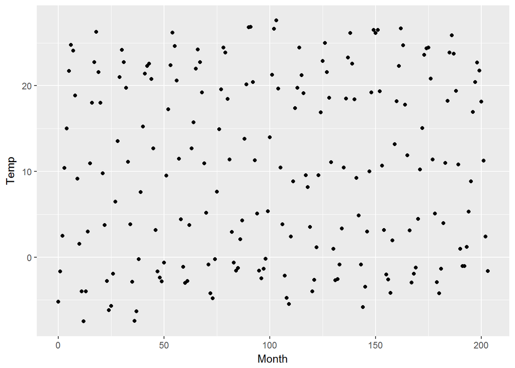

```r
ggplot(aes(x = Month, y = Temp), data = Mitchell) +
    geom_point()
```

### Noisy Scatterplots

1. Take a guess for the correlation coefficient for the scatterplot. 0
2. What is the actual correlation of the two variables? (Round to the thousandths place)

```r
cor.test(Mitchell$Month, Mitchell$Temp, method = 'pearson')
```

```
##
##  Pearson's product-moment correlation
##
## data:  Mitchell$Month and Mitchell$Temp
## t = 0.81816, df = 202, p-value = 0.4142
## alternative hypothesis: true correlation is not equal to 0
## 95 percent confidence interval:
##  -0.08053637  0.19331562
## sample estimates:
##        cor
## 0.05747063
```

### Making Sense of Data

Notes:

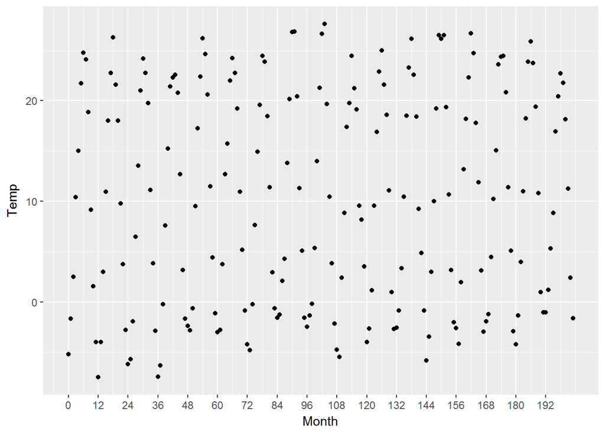

```r
ggplot(aes(x = Month, y = Temp), data = Mitchell) +
    geom_point() +
    scale_x_continuous(breaks = seq(0,203,12))
```

### A New Perspective

What do you notice? Response: the temp rises and falls over a year

Watch the solution video and check out the Instructor Notes! Notes:

### Understanding Noise: Age to Age Months

Notes:

```r
head(pf.fc_by_age, 10)
```

```
## # A tibble: 10 × 4
##      age friend_count_mean friend_count_median     n
##    <int>             <dbl>               <dbl> <int>
## 1     13          164.7500                74.0   484
## 2     14          251.3901               132.0  1925
## 3     15          347.6921               161.0  2618
## 4     16          351.9371               171.5  3086
## 5     17          350.3006               156.0  3283
## 6     18          331.1663               162.0  5196
## 7     19          333.6921               157.0  4391
## 8     20          283.4991               135.0  3769
## 9     21          235.9412               121.0  3671
## 10    22          211.3948               106.0  3032
```

```r
pf$age_with_months <- pf$age + ((12 - pf$dob_month)/12)
head(pf)
```

```
##    userid age dob_day dob_year dob_month gender tenure friend_count
## 1 2094382  14      19     1999        11   male    266            0
## 2 1192601  14       2     1999        11 female      6            0
## 3 2083884  14      16     1999        11   male     13            0
## 4 1203168  14      25     1999        12 female     93            0
## 5 1733186  14       4     1999        12   male     82            0
## 6 1524765  14       1     1999        12   male     15            0
##   friendships_initiated likes likes_received mobile_likes
## 1                     0     0              0            0
## 2                     0     0              0            0
## 3                     0     0              0            0
## 4                     0     0              0            0
## 5                     0     0              0            0
## 6                     0     0              0            0
##   mobile_likes_received www_likes www_likes_received age_with_months
## 1                     0         0                  0        14.08333
## 2                     0         0                  0        14.08333
## 3                     0         0                  0        14.08333
## 4                     0         0                  0        14.00000
## 5                     0         0                  0        14.00000
## 6                     0         0                  0        14.00000
```

### Age with Months Means

```r
library(dplyr)
```

Programming Assignment

```r
ages_in_months <- group_by(pf, age_with_months)

pf.fc_by_age_in_months <- summarise(ages_in_months,
                                    friend_count_mean = mean(friend_count),
                                    friend_count_median = median(friend_count),
                                    n=n())

pf.fc_by_age_in_months <- arrange(pf.fc_by_age_in_months, age_with_months)
head(pf.fc_by_age_in_months)
```

```
## # A tibble: 6 × 4
##   age_with_months friend_count_mean friend_count_median     n
##             <dbl>             <dbl>               <dbl> <int>
## 1        13.16667          46.33333                30.5     6
## 2        13.25000         115.07143                23.5    14
## 3        13.33333         136.20000                44.0    25
## 4        13.41667         164.24242                72.0    33
## 5        13.50000         131.17778                66.0    45
## 6        13.58333         156.81481                64.0    54
```

### Noise in Conditional Means

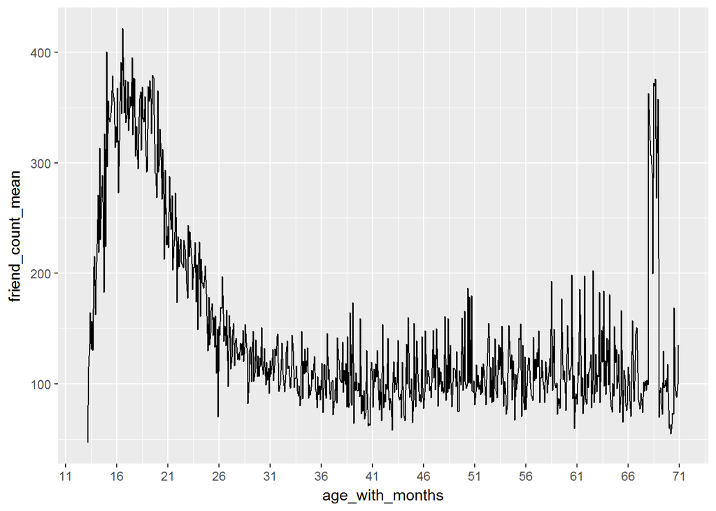

```r
ggplot(aes(x = age_with_months, y = friend_count_mean), data = subset(pf.fc_by_age_in_months, age_with_months < 71)) +
    geom_line() +
    scale_x_continuous(breaks = seq(1,71,5))
```

### Smoothing Conditional Means

Notes:

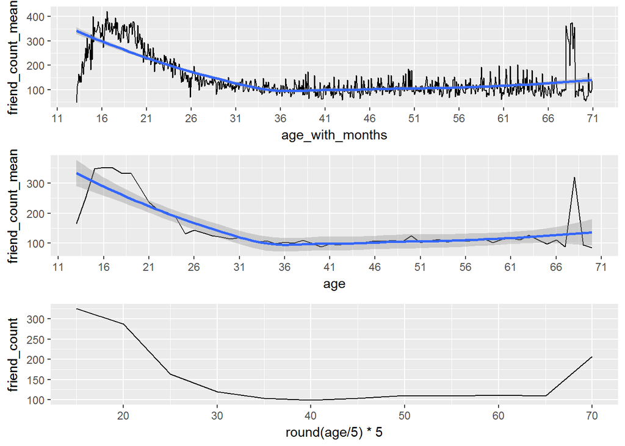

```r
p1 <- ggplot(aes(x = age_with_months, y = friend_count_mean), data = subset(pf.fc_by_age_in_months, age_with_months < 71)) +
    geom_line() +
    geom_smooth() +
    scale_x_continuous(breaks = seq(1,71,5))

p2 <- ggplot(aes(x = age, y = friend_count_mean), data = subset(pf.fc_by_age2, age < 71)) +
    geom_line() +
    geom_smooth() +
    scale_x_continuous(breaks = seq(1,71,5))

p3 <- ggplot(aes(x = round(age / 5) * 5, y = friend_count),
             data = subset(pf, age < 71)) +
    geom_line(stat = 'summary', fun.y = mean)

library(gridExtra)
grid.arrange(p1,p2,p3,ncol=1)
```

### Which Plot to Choose?

Notes:

### Analyzing Two Variables

Reflection:

Click **KnitHTML** to see all of your hard work and to have an html page of this lesson, your answers, and your notes!